# Simulating decomposition of a litter bag

## Model versions

- SESAM4a: soil enzyme steady allocation model with microbial turnover rate by predation increases linearly with microbial biomass.

### Setup parameters and drivers

Mass units are $gC/m^2$, $gN/m^2$ or $gP/m^2$. Time unit is $yr$.

```r
require(sesam)
parms0 <- list(
  cnB = 8.3       ##<< Cleveland07, grassland
  , cnBW = 8.4    ##<< C/N ratio of cell material that go to RC (cell walls) NRSOM Tipping 16
  , cnE = 3.2     # Sterner02: Protein (Fig. 2.2.), high N investment (low P)
  , cnIR = 4.5     ##<< between micr and enzyme signal
  , cnIL = 30      ##<< N litter OM
  , kmN = 0.3*0.01*365  ##<< /yr enzyme turnover 1% turning over each day
  , kNB = 0.8      ##<< amount of recycling enzyme turnover by biomass (added to uptake instead of RC)
  , kR = 1/(50)    ##<< 1/(x years)
  #, kL = 1/(1)     ##<< 1/(x years)
  , kL = 1/(5/365)     ##<< 1/(5 days) # for the priming study
  #, kL = 1/(2/12)  ##<< two months # for the litter bag decomposition
  , aE = 0.001*365 ##<< C biomass allocated to enzymes gC/day /microbial biomass
  #, km = 0.3       ##<< enzyme half-saturation constant
  , m = 0.02*365   ##<< maintenance respiration rate   gC/day /microbial biomass
  , tau = 1/60*365/5 ##<< biomass turnover rate (12 days), devided by 5 without predation
  , eps = 0.5      ##<< carbon use efficiency
  , epsPred = 0.3  ##<< carbon use efficiency of microbial tvr (predators respire)
  , iR = 0         ##<< input modelled explicitely
  , iL = 300       ##<< g/m2 input per year (half NPP)
  , plantNUp = 0   ##<< plant N uptake balancing N inputs
  , useFixedAlloc = FALSE    ##<< set to true to use fixed enzyme allocation (alpha = 0.5)
  , kIPlant = 10.57 #0.0289652*365         ##<< plant uptake iP I
  , iB = 0.38 * 10.57 #0.0110068*365   ##<< immobilization flux iB I
  , iI = 0         ##<< input of mineral N
  , l = 0.96 #0.00262647*365       ##<< leaching rate of mineralN l I
  , nu = 0.9       ##<< microbial N use efficiency
  , isEnzymeMassFlux = TRUE  ##<< steady state BC solution accounts for enyzme mass fluxes
  , nuP = 0.3      ##<< microbial uptake of depolymerized P, (1-nuP) is mineralized
  , cpE = 100     ##<< Sterner02, protein with no P
  , cpB = 47.3    ##<< Cleveland07, grassland
  , cpBW = 61     ##<< NRSOM Tipping16
  , cpIR = 61
  , cpIL = 919    ##<< NPSOM Tipping 16
  , iBP = 0.38 * 10.57 # start with same as N
  , cW = 0.8 # proportion of cell wall within microbial biomass
  , B0 = 0  # minimal biomass, below which predation rate is zero
  #, tauP = 0.2 # slope of predation rate with biomass
  , tauP = 0.5 # slope of predation rate with biomass
  , nuP = 0.01 # DOP almost all mineralized before taken up
)
parms0 <- within(parms0,{
  #kmR <- kmL <- km
  #eps1 <- eps2 <- eps
  #cnER <- cnEL <- cnE
  #kNR <- kNL <- kN
  kIPlant <- plantNUpAbs <- 0           # no plant uptake
  lP <- l       # leaching rate of inorganic P equals that of N
  kIPPlant <- kIPlant  # plant uptake rate of P equals that of N
  iIP <- l      # assume no P inputs compensate for leaching
})
# assure no P-limitation
parms0 <- within(parms0,{
  lP <- kIPPlant <- 0   # no leading of P
  iBP <- 1e6            # no limit of P immobilization flux
})
# assure no limitaiton by abiotic N
parms0 <- within(parms0,{
  lI <- kIPlant <- 0    # no leading of P
  iB <- 1e6            # no limit of P immobilization flux
})
# neglect influence of inorganic pools (keep them at fixed initial values)
parms0$isFixedI <- TRUE
```

For simplicity model drivers are currently prescibed as constant parameters.

```r
drivers <- list(
  iR = 0           ##<< input of residue litter
  #, iL = 0         ##<< input of labile litter
  , iL = 5         ##<< input of labile litter assume some DOC to prevent biomass depletion
  , cnIR = 7       ##<< C/N ratio of the residue litter input
  , cnIL = 30      ##<< C/N ratio of labile litter input
  , cpIR = 40      ##<< C/P ratio of the residue litter input
  , cpIL = 919     ##<< C/P ratio of the labile litter input, NPSOM Tipping16
  , iI = 0         ##<< input of mineral N
  , iIP = 0        ##<< input of labile mineral P
)
parms0 <- c(parms0[setdiff(names(parms0),names(drivers))], drivers)
```

The initial pools must be specified.

```r
x0 <- c( #aE = 0.001*365
  BC = 85                    ##<< microbial biomass in C units
  , RC = 1                   ##<< C residue OM
  , RN = 1/parms0$cnIR      ##<< N residue OM
  , RP = 1/parms0$cpIR      ##<< P residue OM
  , LC = 1000                ##<< C litter OM
  , LN = 1000/parms0$cnIL   ##<< N litter OM
  , LP = 1000/parms0$cpIL   ##<< P litter OM
  , I =  0.01               ##<< inorganic pool
  , IP =  0.01              ##<< inorganic pool
  , alpha = 0.0             ##<< microbial community partitioning [0,1]
)
```

# Run decomposition simulation

```r
times <- c(seq(0,2/12, length.out = 101),seq(2/12,2,length.out = 101)[-1],seq(2,20,length.out = 31)[-1])
res <- res1 <- as.data.frame(lsoda( x0, times, derivSesam4a, parms = parms0))
xE <-  unlist(tail(res,1)) # final state
x0S <- xE[1 + seq_along(x0)]
```

Plot time course.

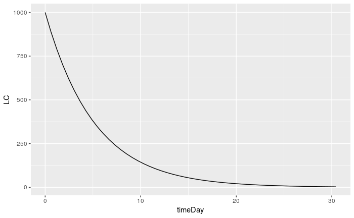

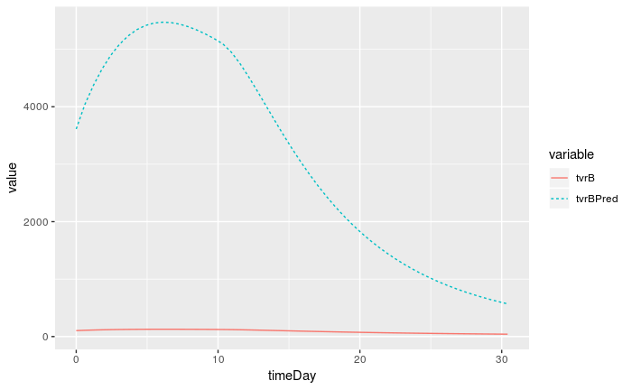

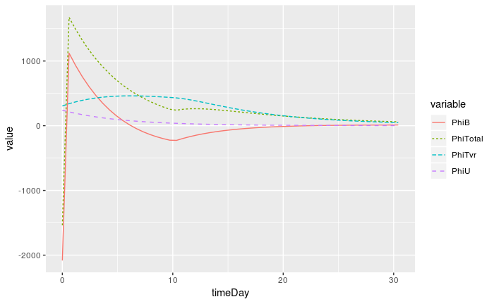

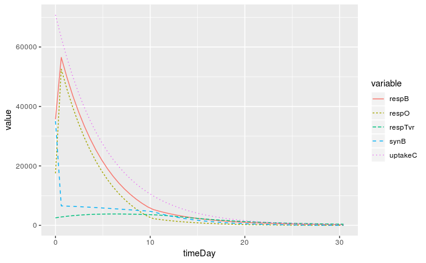

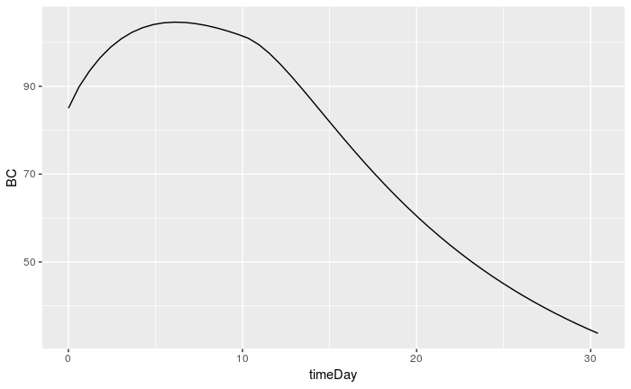

## Inspecting C/N ratios and CUE

Microbial community changes take longer.

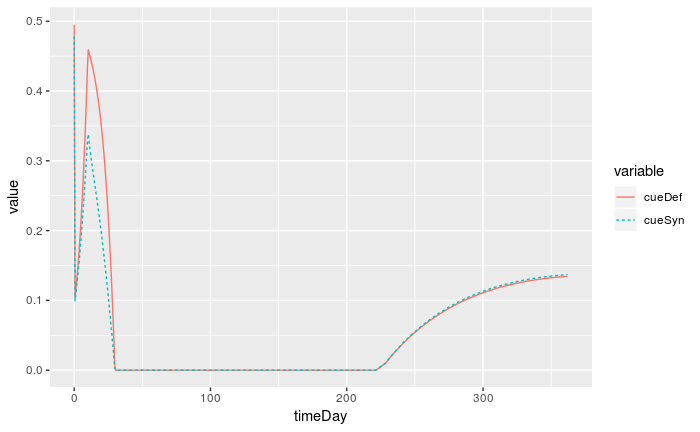

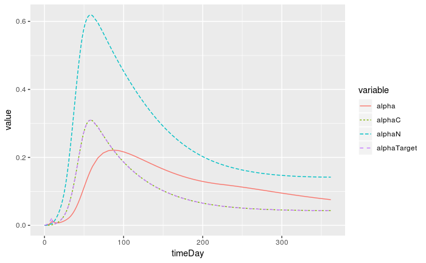

course of C:N relative to initial values

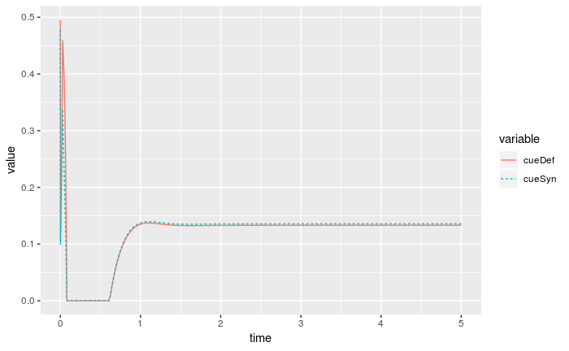

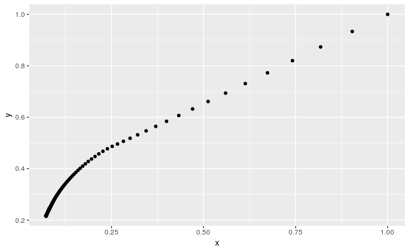

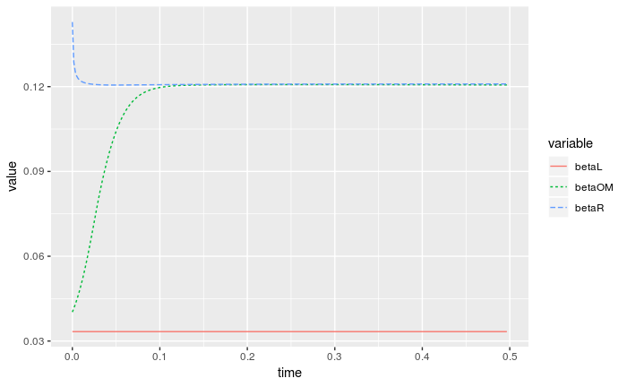

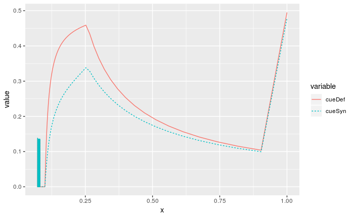

For inferring CUE from litterbags, C0 should be only the first removal of a litter bag, instead of the initial litter concentrations.

For the studied litter decomposition, the system stabilized after about 1 yr, but then it consists almost solely of residue pool RC, and assumed trickling inputs into the fresh pool.

The initial missing N accumulation which is ascribed to lower CUE in Manzoni17, is probably due to limitation of immobilization flux. But what can we learn from it?

TODO: show a simulation with limited immobilization flux.

## Oscillations

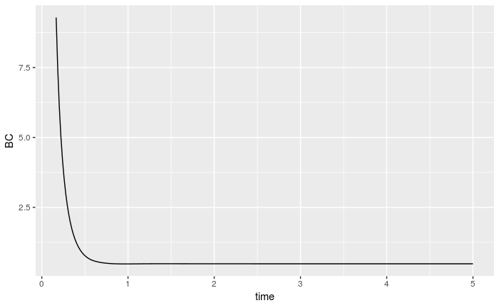

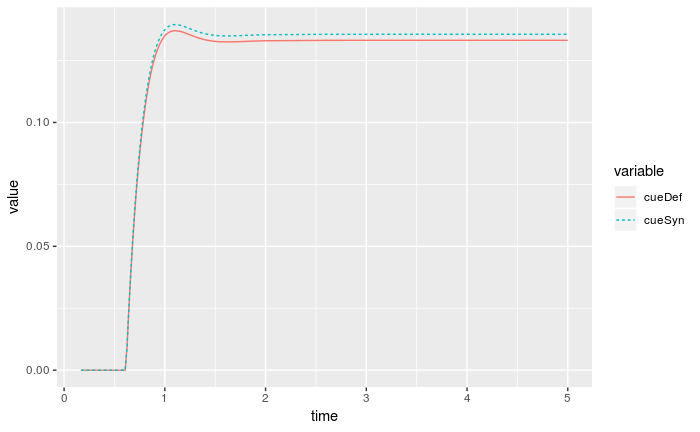

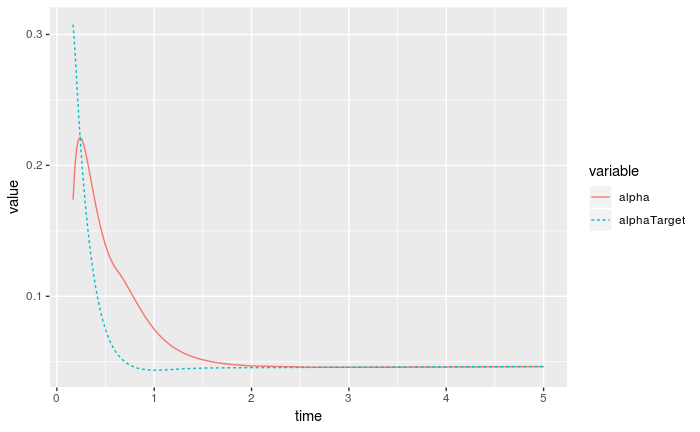

The LC is not depleted yet, but cannot deliver enough carbon to sustain biomass.

# Priming spike

Simulate a spike of fresh litter on exhausted biomass.

```r
x02 <- x0S
LC <- 200
x02["BC"] <- 1e-8
x02["LC"] <- LC
x02["LN"] <- LC/parms0$cnIL
x02["LP"] <- LC/parms0$cpIL
  times1 <- c(seq(0,1/12, length.out = 51), seq(1/12,1, length.out = 51)[-1])
  res <- res2 <- as.data.frame(lsoda( x02, times1, derivSesam4a, parms = parms0))
  xE2 <-  unlist(tail(res,1)) # final state
  x0S <- xE[1 + seq_along(x0)]
```

Plot time course.

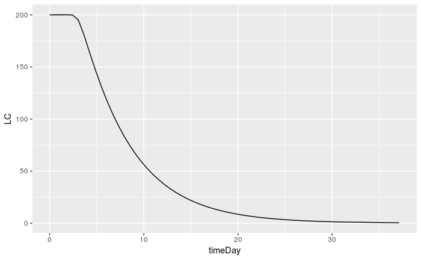

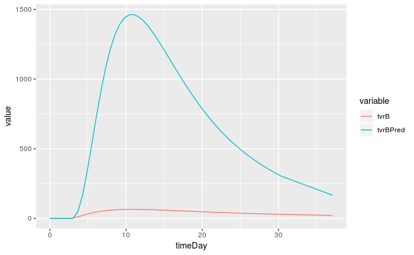

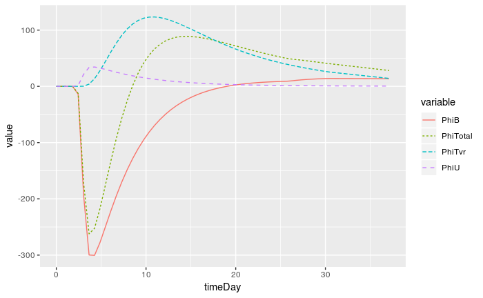

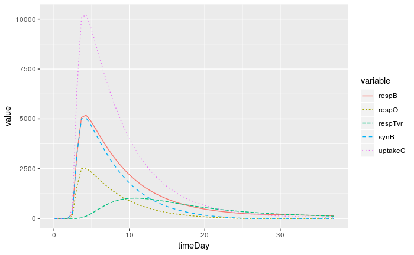

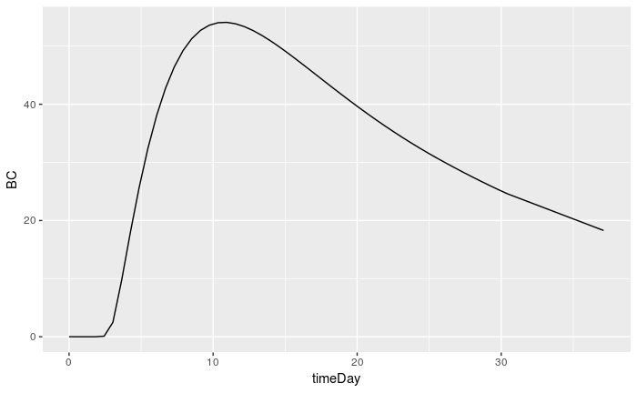

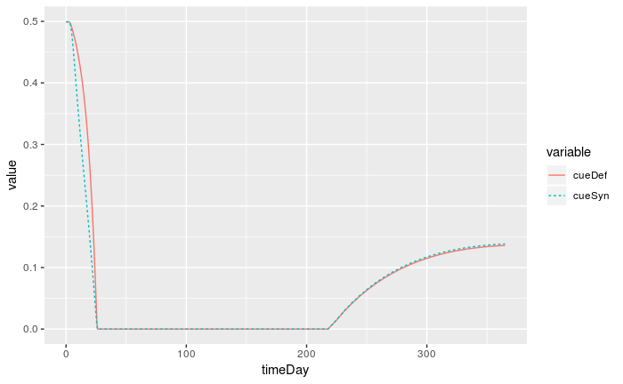

```r
# CUE
resAgg <- resC1 %>% select(timeDay, cueDef, cueSyn) %>% gather(key = "variable", "value", -timeDay)
ggplot( resAgg, aes(timeDay, value, color = variable, linetype = variable)) + geom_line()
```

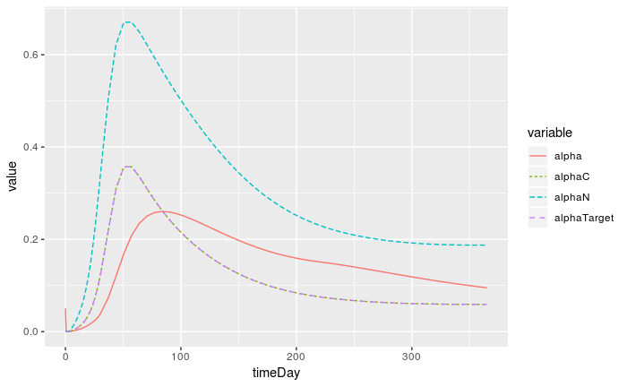

```r
# elemental limitations
# resAgg <- resC %>% select(timeDay, limC, limN, limP) %>% gather(key = "variable", "value", -timeDay)
# ggplot( resAgg, aes(timeDay, value, color = variable, linetype = variable)) + geom_line()
# resAgg <- resC %>% select(timeDay, CsynBC, CsynBN) %>% gather(key = "variable", "value", -timeDay)
# ggplot( resAgg, aes(timeDay, value, color = variable, linetype = variable)) + geom_line()
resAgg <- resC1 %>% select(timeDay, alpha, alphaTarget, alphaC, alphaN) %>%
  gather(key = "variable", "value", -timeDay)
ggplot( resAgg, aes(timeDay, value, color = variable, linetype = variable)) + geom_line()
```